# Exploring cellhash data

Josh Shapiro for CCDL

This notebook explores processing cellhash data, separating samples by hashed barcodes.

# Set Up

Libraries:

```r
suppressPackageStartupMessages({
  library(ggplot2)
  library(SingleCellExperiment)
  library(scater)
  library(bluster)
  library(Seurat)
})

theme_set(theme_bw())
```

File paths:

```r
file_dir <- file.path("data", "cellhash")

# test sce files
# These files are the from the Christensen Pool1 sample
unfiltered_file <- file.path(file_dir, "SCPCL000533_unfiltered.rds")
filtered_file   <- file.path(file_dir, "SCPCL000533_filtered.rds")

# CITE-seq-count results
csc_dir <- file.path(file_dir, "SCPCL000533_csc_umi")
```

# Initial look at SCE objects

The initial mapping that we performed used `alevin-fry` to separately map and quantify RNA-seq reads and hash tag oligos (HTOs), assigning counts to droplets. These results were then read into R and saved as a `SingleCellExperiment` object, combining the two sets of data. Here we are reading in those data, both from an unfiltered file and one where the droplets have been filtered to those likely to contain cells, based on the RNA-seq data.

```r
sce_unfiltered <- readRDS(unfiltered_file)
sce_filtered <- readRDS(filtered_file)
```

How many cells are in each of these files?

```r
ncol(sce_unfiltered)
```

```
[1] 145923
```

```r
ncol(sce_filtered)
```

```
[1] 82017
```

The number of cells after filtering empty drops is very high!

### HTO count patterns

Both of these files have an `altExp` named `"cellhash"`.

When we merge in feature data as part of `scpca-nf` workflow, we add zeros for any cells which do appear in the expression data, but do not appear in cellhash data. While in the case of CITE-seq this may make sense, in the case of cell hashing, a cell with no hash data is going to be impossible to assign.

Let’s see how often that happened here, by looking at the distribution of cell read counts:

```r
cell_metrics <- data.frame(colData(sce_unfiltered)) |>
  tibble::rownames_to_column("cell_barcode") |>
  dplyr::mutate(filter_status = ifelse(
    cell_barcode %in% colnames(sce_filtered),
    "cell",
    "empty"))
```

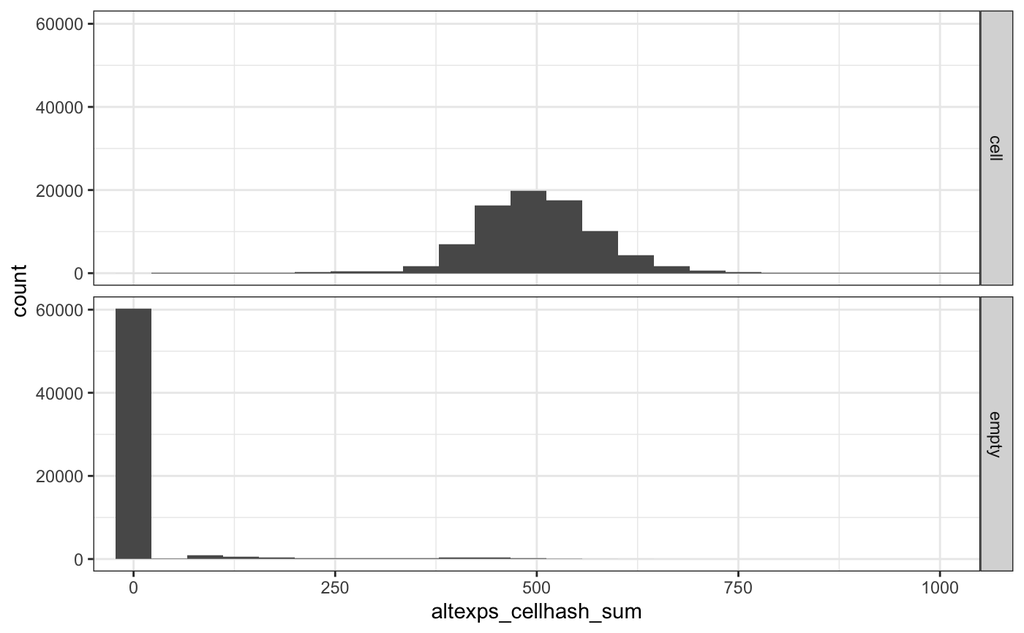

```r
ggplot(cell_metrics, aes(x = altexps_cellhash_sum))+
  geom_histogram(bins = 100) +
  facet_grid(filter_status ~ .) +
  coord_cartesian(xlim = c(0, 1000))
```

Good, most of the empty drops that we filtered out don’t have any cellhash data, and most of the cells we keep do!

We’ll proceed with just filtered data for now, but we might want to consider how we handle the unfiltered data in these cases… It doesn’t make sense to keep the zero-cellhash cells (unless we add an “unassigned” class which we might have to come back to), but that will filter out most of the empty drops anyway (so the resulting `_unfiltered` but split library will probably not have many empty cells…)

```r
# drop the unfiltered data to save space
rm(sce_unfiltered)
```

# The cellhash data

Let’s start looking at the cellhash data.

```r
# pull the hash data (from filtered cells) into a separate object
hash_sce <- altExp(sce_filtered, "cellhash")

hash_data <- rowData(hash_sce) |>
  as.data.frame() |>
  tibble::rownames_to_column("HTO")
hash_data
```

| HTO | mean | detected |
| --- | --- | --- |
| MULTI_1 | 1.512891e+02 | 99.991465184 |
| MULTI_2 | 1.495728e+02 | 99.990245925 |
| MULTI_3 | 7.868865e+01 | 99.991465184 |
| MULTI_4 | 1.295971e+02 | 99.991465184 |
| MULTI_5 | 5.852445e-04 | 0.058524452 |
| MULTI_6 | 7.925186e-04 | 0.079251862 |
| MULTI_7 | 6.584001e-04 | 0.065840009 |
| MULTI_8 | 1.248522e-02 | 0.990038651 |
| MULTI_9 | 4.877038e-05 | 0.004877038 |
| MULTI_10 | 1.341185e-04 | 0.013411854 |

[output cut: 2 more lines]

This sample seems to use barcodes 1-4, and all are found in every cell.

Let’s reduce our hash data to just those:

```r
hash_sce <- hash_sce[1:4,]
```

Now let’s look at the first 20 cells:

```r
t(counts(hash_sce)[,1:20])
```

```
20 x 4 sparse Matrix of class "dgCMatrix"
                 MULTI_1 MULTI_2 MULTI_3 MULTI_4
ACACGCGGTAGCGAGT     192     282     112     179
CACGAATGTTGTCTAG     159     163      76     132
TCATGTTTCGCAATTG     280     249     192     189
CCTCAACTCCTGTTGC     262     196      88     149
CGCATGGGTACTCAAC     140     282      78     114
TTGCATTGTGCTATTG     132     174      75      96
GTCCTCACAGCCTACG     185     235      81     128
TCATCATCAGTAACAA     227     196      64     139
CTCAACCCAGGATCTT     368     367     157     300
GCATCTCCAGCTGTAT     165     206      56     145
TTGGGTAAGTGCTCAT     135     188      51      85
AGACAAATCGTAGCCG     220     224     103     223
CATAGACTCCGTAGTA     175     160      75     145
CAAGACTTCCTTTAGT     201     169      81     165
AGTACCAGTATGCAAA     207     118      68      84
CGGAACCCACGCAGTC     173     130      57      83
GCAACATTCTTTGCGC     188     120      58      82
ATCACTTCAACACTAC     131     223      81     137
AGCCAGCAGGTCGTAG     236     192      79     137
GGACGTCTCGGCCAAC     130     148     163     129
```

There is some variation there, but the overall counts seem very similar across cells; it may be difficult to assign cells confidently.

Let’s see if there is much clustering among cells.

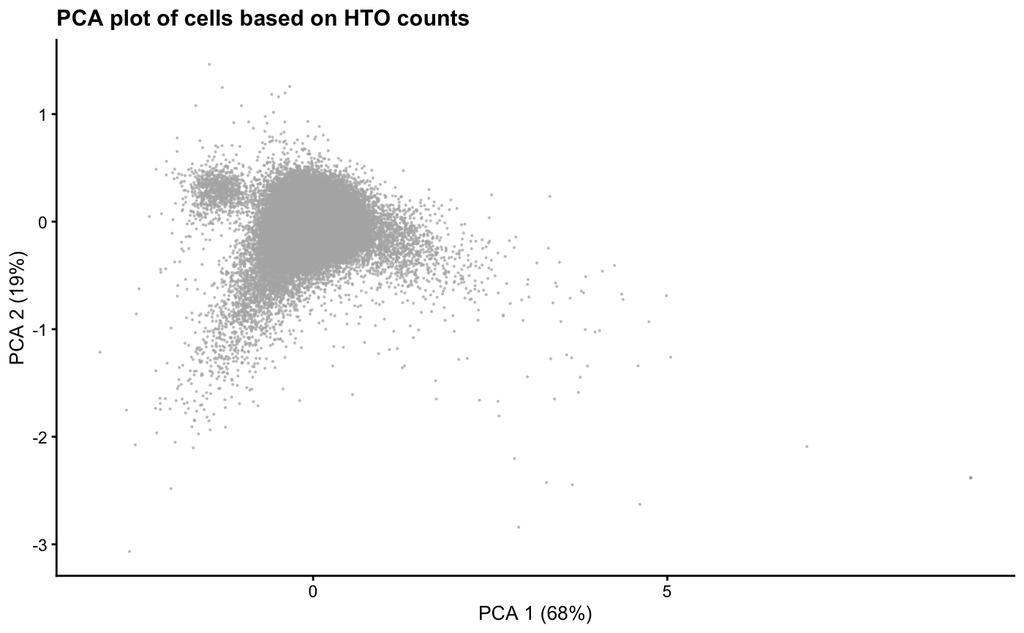

```r
# add a log counts matrix (no normalization)
logcounts(hash_sce) <- log1p(counts(hash_sce))
# calculate pca
hash_sce <- scater::runPCA(hash_sce,
                           ncomponents = 4,
                           BSPARAM=BiocSingular::ExactParam())
# plot pca
scater::plotPCA(hash_sce, point_size = 0.1) +
  ggtitle("PCA plot of cells based on HTO counts")
```

Looks like there may be a few potential clusters there, but overal it is pretty diffuse. We do not see the 4 distinct clusters that we might have expected. I’m not sure how confidently we will be able to deconvolute.

## Assigning cells with `hashedDrops`

First we will run `hashedDrops` with default settings, on the filtered data. This uses a pretty simple method of identifying ambient tag patterns, remove that, and then look for the highest expressed HTO for assignment.

```r
hash_result <- DropletUtils::hashedDrops(hash_sce)

metadata(hash_result)
```

```
$ambient
  MULTI_1   MULTI_2   MULTI_3   MULTI_4
130.56234 127.47033  65.62994 107.25034

$confident.threshold
[1] 2

$doublet.threshold
[1] 2
```

That looks like a pretty high level of estimated ambient HTO counts.

How many calls were confidently made?

```r
sum(hash_result$Confident)
```

```
[1] 108
```

Let’s look at the “confident” calls in a bit more depth:

```r
confident_calls <- hash_result |>
  as.data.frame() |>
  dplyr::filter(Confident)

dplyr::count(confident_calls, Best)
```

| Best | n |
| --- | --- |
| 1 | 1 |
| 2 | 13 |
| 3 | 81 |
| 4 | 13 |

That isn’t so good. Only 108 total cells called of tens of thousands. It really looks like the background level of all HTOs is too high, or something else is wrong.

We can look at the log fold change value distribution between the best and second best HTO: we would expect to see large values here:

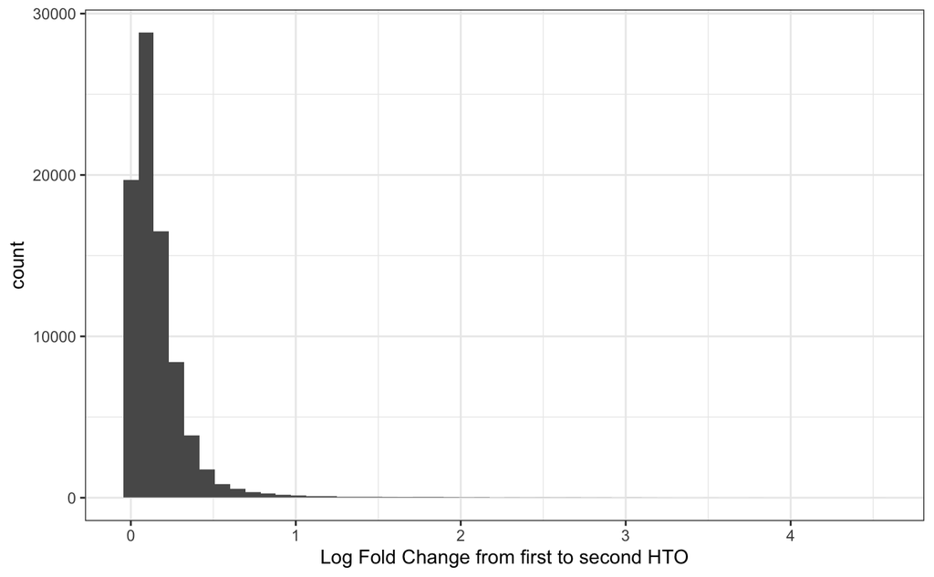

```r
ggplot(mapping = aes(x = hash_result$LogFC)) +
  geom_histogram(bins = 50)+
  labs(x = "Log Fold Change from first to second HTO")
```

Not much with even a 2-fold change, which makes it very hard to assign cells confidently. We could lower the threshold, but that seems fraught.

## Assigning cells with Seurat

```r
# filter out cells with low HTO counts, & reduce to only the first 4 HTOs
sce_filtered <- sce_filtered[,sce_filtered$altexps_cellhash_sum > 50]
altExp(sce_filtered) <- altExp(sce_filtered)[1:4,]

# create a Seurat object
seurat_obj <- Seurat::CreateSeuratObject(counts(sce_filtered))
seurat_obj[["HTO"]] <- CreateAssayObject(counts = counts(altExp(sce_filtered)))
seurat_obj <- Seurat::NormalizeData(seurat_obj, assay = "HTO", normalization.method = "CLR")
```

```
Normalizing across features
```

```
  |                                                  | 0 % ~calculating
  |+++++++++++++                                     | 25% ~00s
  |+++++++++++++++++++++++++                         | 50% ~00s
  |++++++++++++++++++++++++++++++++++++++            | 75% ~00s
  |++++++++++++++++++++++++++++++++++++++++++++++++++| 100% elapsed=00s
```

```r
seurat_obj <- Seurat::HTODemux(seurat_obj)
```

```
Cutoff for MULTI-1 : 181 reads
Cutoff for MULTI-2 : 177 reads
Cutoff for MULTI-3 : 85 reads
Cutoff for MULTI-4 : 153 reads
```

This worked, though with at least one other sample it failed for unknown reasons, so we may not want to rely on it.

I’m also generally uncomfortable with the fact that it seems to call samples based on a relatively simple cutoff for each HTO;

Let’s look at the results:

```r
table(seurat_obj$HTO_classification.global)
```

```
 Doublet Negative  Singlet
   11845    52451    17708
```

So it looks like it did make calls for a much larger number of cells, but the majority are still not being assigned to a single sample, and there are a very large number of “doublets.” How confident are those calls?

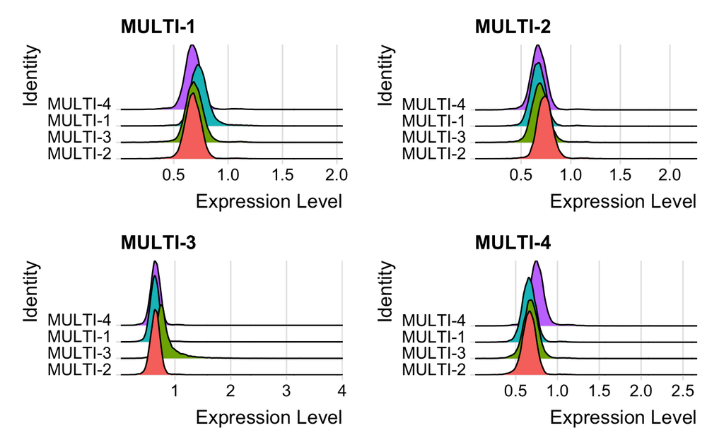

```r
# Group cells based on the max HTO signal
Idents(seurat_obj) <- "HTO_maxID"
RidgePlot(seurat_obj, assay = "HTO", features = rownames(seurat_obj[["HTO"]])[1:4], ncol = 2)
```

I would not call those super-impressive differences. A very slight upward bias for th matching oligo, but that would be expected given the procedure being used to assign the cells requires it.

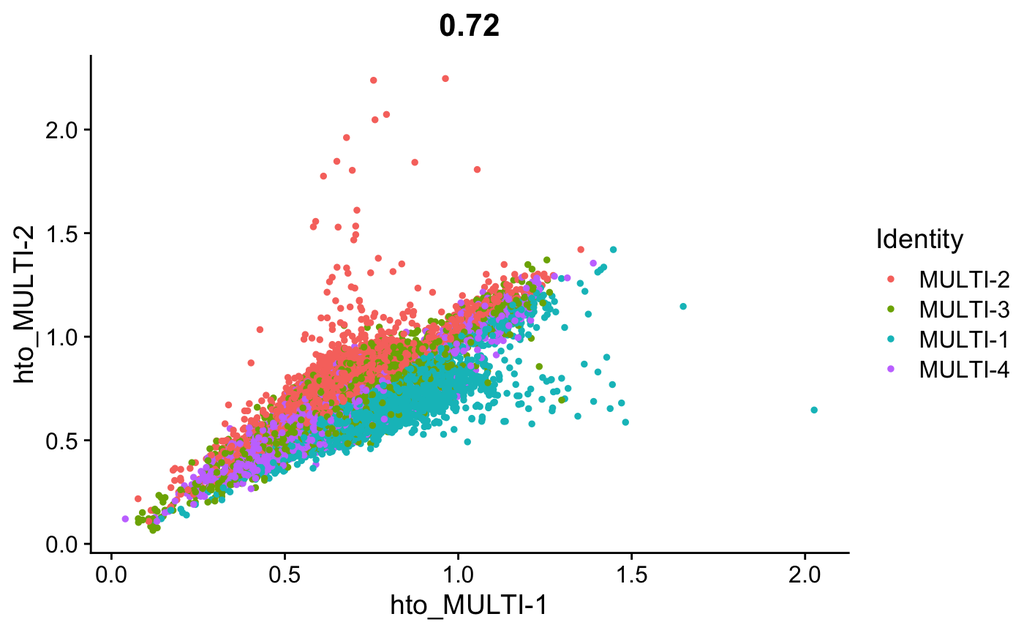

```r
FeatureScatter(seurat_obj, feature1 = "hto_MULTI-1", feature2 = "hto_MULTI-2")
```

We would expect the MULTI-1 and MULTI-2 samples to lie more along the axes here, away from the center, but they are not well-differentiated in general.

Overall, I am not confident that the called cells are very reliable based on these data.

```r
# clean up Seurat
rm(seurat_obj)
```

# Alternative mapping

We also performed mapping with CITE-seq-count just to check that the alevin-fry results were reasonable. We can read those results separately.

We specified 50,000 cells when we ran this (it did not seem to like the whitelist option it claimed to support)

```r
csc_counts <- as.matrix(Matrix::readMM(file = file.path(csc_dir, "matrix.mtx.gz")))
csc_barcodes <- readr::read_tsv(file.path(csc_dir, "barcodes.tsv.gz"),
                                col_names = FALSE,
                                col_types = 'c')$X1
csc_features <- readr::read_tsv(file.path(csc_dir, "features.tsv.gz"),
                                col_names = FALSE,
                                col_types = 'c')$X1

dimnames(csc_counts) <- list(csc_features, csc_barcodes)
```

Let’s look at the first few rows:

```r
t(csc_counts[1:4,1:20])
```

```
                 MULTI_1-GGAGAAGA MULTI_2-CCACAATG MULTI_3-TGAGACCT MULTI_4-GCACACGC
TTCCTAACACTTGTGA               31               59               43               95
GTAACACGTTCTAAGC               26               57               34               65
CTAACTTCAGATAAAC               47               74               41               80
AAACGCTAGGTGATCG               48               62               68               75
GAGATGGGTACGGGAT               57               45               35               66
TCAAGCACAATCGCGC               36               58               36               63
TACATTCGTTCAAGTC               34               60               36               58
ATTCCATGTGAGGATC               25               49               39               72
GTCACTCTCTGGAGAG               52               54               36               65
GTGTGGCAGCCTGTCG               45               64               34               53
AGTGCCGGTTCATCGA               31               53               31               64
TCACGGGCACAATCTG               44               62               31               55
CAATACGCAAGAGGTC               25               55               35               61
TTCTTCCGTAGACAAT               31               54               34               56
CGTAGTAGTCGTTGGC               37               60               33               56
TGCTTGCTCGAACACT               45               66               32               48
GATTTCTTCGTTGTAG               36               56               29               55
AGCGATTCACTCATAG               56               65               47               60
CTATAGGAGAAGGATG               35               66               43               62
ACAAAGAAGCCAGACA               38               60               37               54
```

Looks like basically the same story: It does not appear that our mapping system was at fault. There is a very high background level of each HTO, which will likely make assignment difficult.

# Expression data

Let’s just look quickly at the expression data to see if that looks as we would expect. We will plot some basic cell metrics, including mitochondrial percent.

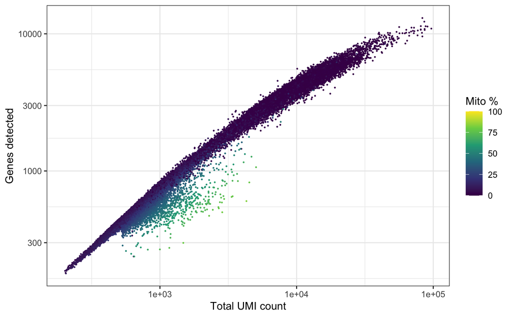

```r
cell_metrics <- colData(sce_filtered)|>
  as.data.frame()|>
  tibble::rownames_to_column("barcode")
ggplot(cell_metrics, aes(x = sum, y = detected, color = subsets_mito_percent)) +
  geom_point(size = 0.2) +
  theme_bw() +
  scale_x_log10() +
  scale_y_log10() +
  scale_color_continuous(type = "viridis", limit = c(0,100)) +
  labs(x = "Total UMI count",
       y = "Genes detected",
       color = "Mito %")
```

Aside from having lots of cells, that looks pretty normal. Let’s add some more aggressive filtering for now.

```r
pass_barcodes <- cell_metrics |>
  dplyr::filter(detected > 500,
                prob_compromised < 0.8 | subsets_mito_percent < 10) |>
  dplyr::pull(barcode)
sce_filtered <- sce_filtered[, pass_barcodes]
```

Now we will perform normalization:

```r
qclust <- scran::quickCluster(sce_filtered)
sce_filtered <- sce_filtered |>
  scran::computeSumFactors(clusters = qclust) |>
  scater::logNormCounts()
```

And some dimension reduction with UMAP:

```r
sce_filtered <- sce_filtered |>
  scater::runPCA() |>
  scater::runUMAP()
```

Plot the UMAP results:

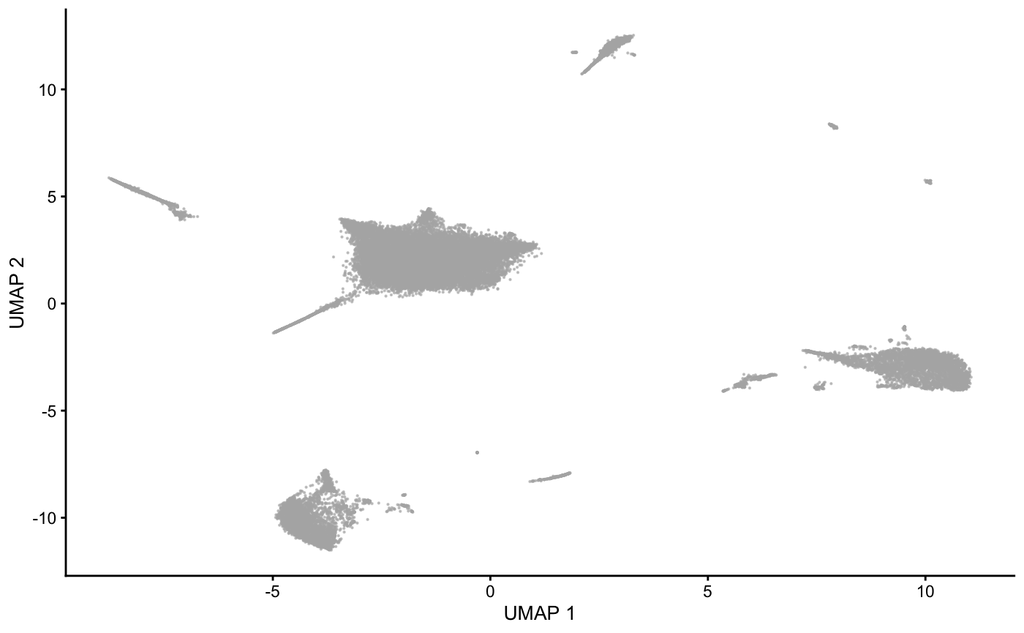

```r
scater::plotUMAP(sce_filtered, point_size = 0.1)
```

There does seem to be some normal-ish looking structure there, but of course without any context, there is little to interpret! Are the clusters different cell types or different samples?

|  | setting | value |
| --- | --- | --- |
| version | version | R version 4.1.1 (2021-08-10) |
| os | os | macOS Monterey 12.0.1 |
| system | system | x86_64, darwin17.0 |
| ui | ui | RStudio |
| language | language | (EN) |
| collate | collate | en_US.UTF-8 |
| ctype | ctype | en_US.UTF-8 |
| tz | tz | America/New_York |
| date | date | 2021-11-04 |